# MPDW pertemuan 6

Muhammad Abshor Dzulhij Rizki_G1401221038

2024-09-30

```r
library(ggplot2)
library(tsibble)
library(tseries)
library(MASS)
library(forecast)
library(TSA)
library(TTR)
library(aTSA)
library(graphics)
```

### Impor Data*

```r
library(readxl)
data<- read_excel("C:\\Users\\Jidan statistik\\Downloads\\Data Hujan Bogor 2023-Now.xlsx")

#memasukan data hanya baris 363 hingga 483 aja
data1<-data[363:483,]
```

```r
head(data1)
```

```
## # A tibble: 6 × 1
##   `Akumulasi Hujan`
##               <dbl>
## 1              67.4
## 2              48.3
## 3             187.
## 4              65.9
## 5             116.
## 6             140.
```

```r
str(data1)
```

```
## tibble [121 × 1] (S3: tbl_df/tbl/data.frame)
##  $ Akumulasi Hujan: num [1:121] 67.4 48.3 187 65.9 116.2 ...
```

### Eksplorasi Data*

```r
data1.ts<-ts(data1$`Akumulasi Hujan`)
summary(data1.ts)
```

```
##     Min.  1st Qu.   Median     Mean  3rd Qu.     Max.
##   0.0001  10.4479  36.2017  57.8091  95.7683 341.5969
```

### Plot *Time Series*

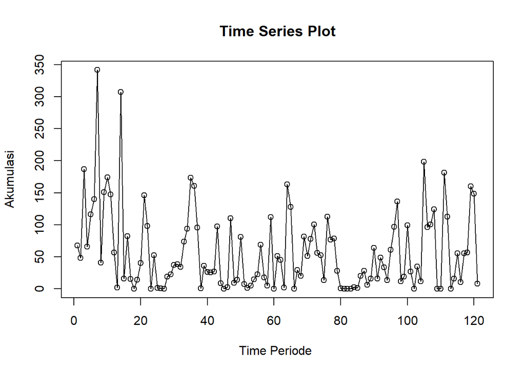

```r
ts.plot(data1.ts, xlab="Time Periode ", ylab="Akumulasi",
        main = "Time Series Plot")
points(data1.ts)
```

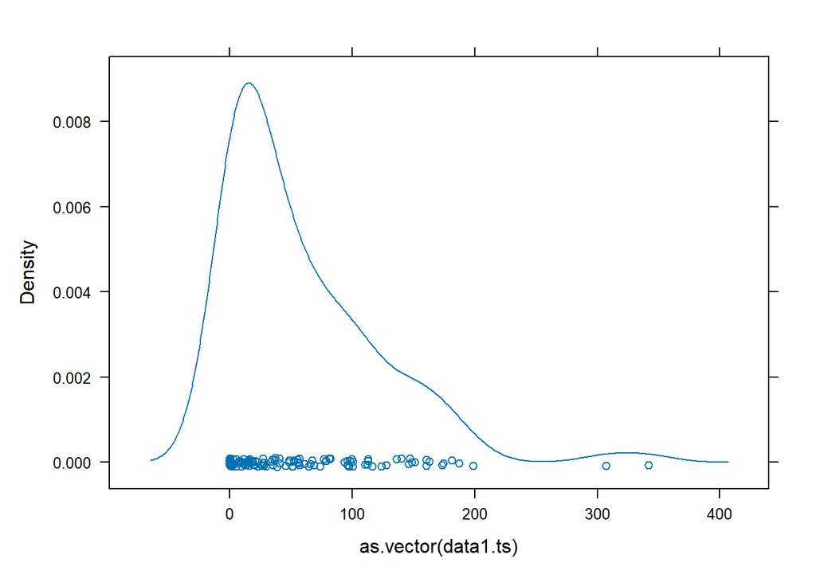

```r
lattice :: densityplot(as.vector (data1.ts))
```

```r
mean(density(data1.ts)$x)
```

```
## [1] 170.7985
```

### Plot ACF

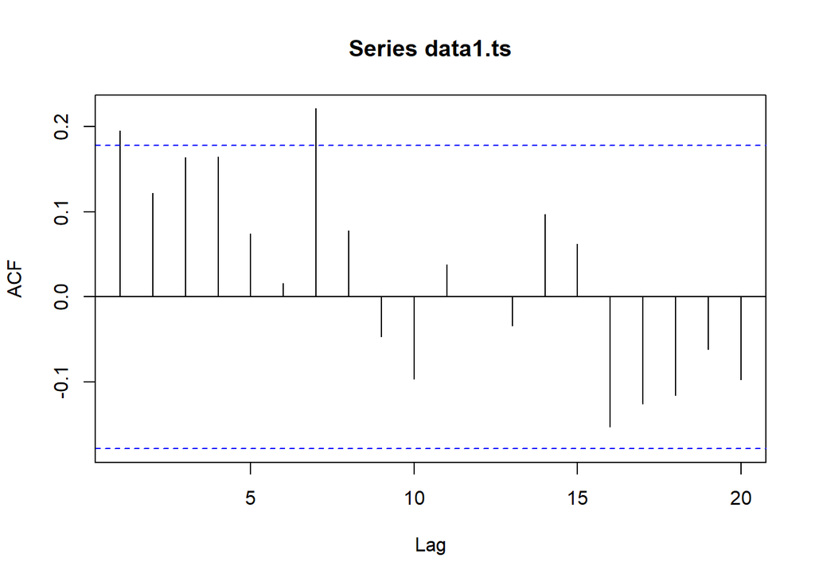

```r
acf(data1.ts)
```

Berdasarkan plot ACF, terlihat bahwa plot ACF pada data tersebut cenderung *tails off* dan membentuk gelombang sinus.

### Uji ADF

```r
tseries::adf.test(data1.ts)
```

```
##
##  Augmented Dickey-Fuller Test
##
## data:  data1.ts
## Dickey-Fuller = -3.5739, Lag order = 4, p-value = 0.03859
## alternative hypothesis: stationary
```

$H_0$ : Data tidak stasioner dalam rataan

$H_1$ : Data stasioner dalam rataan

Berdasarkan uji ADF tersebut, didapat *p-value* sebesar 0.03859 yang lebih kecil dari taraf nyata 5% sehingga tolak $H_0$ dan menandakan bahwa data stasioner dalam rataan. Hal ini sesuai dengan hasil eksplorasi menggunakan plot time series dan plot ACF.

### Plot Box-Cox

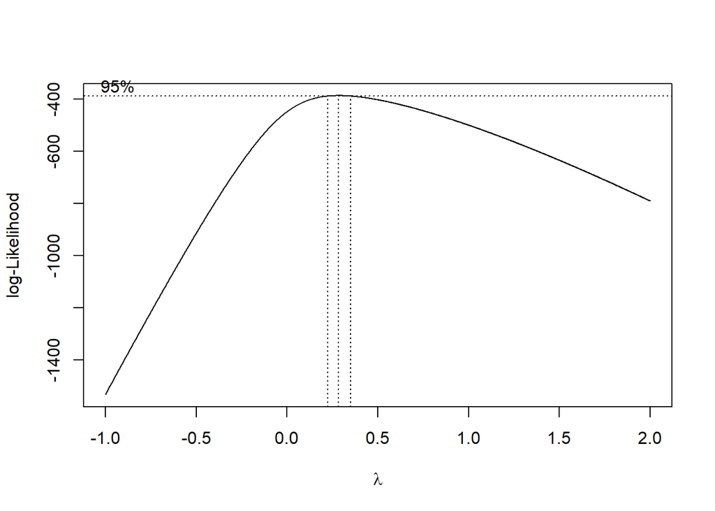

```r
indeks <- seq(1:121)
bc = boxcox(data1.ts~indeks, lambda = seq (-1, 2, by = 0.001))
```

```r
lambda<- bc$x[which.max(bc$y)]
lambda
```

```
## [1] 0.284
```

```r
bc$x[bc$y > max(bc$y) - 1/2 * qchisq(.95,1)]
```

```
##   [1] 0.224 0.225 0.226 0.227 0.228 0.229 0.230 0.231 0.232 0.233 0.234 0.235
##  [13] 0.236 0.237 0.238 0.239 0.240 0.241 0.242 0.243 0.244 0.245 0.246 0.247
##  [25] 0.248 0.249 0.250 0.251 0.252 0.253 0.254 0.255 0.256 0.257 0.258 0.259
##  [37] 0.260 0.261 0.262 0.263 0.264 0.265 0.266 0.267 0.268 0.269 0.270 0.271
##  [49] 0.272 0.273 0.274 0.275 0.276 0.277 0.278 0.279 0.280 0.281 0.282 0.283
##  [61] 0.284 0.285 0.286 0.287 0.288 0.289 0.290 0.291 0.292 0.293 0.294 0.295
##  [73] 0.296 0.297 0.298 0.299 0.300 0.301 0.302 0.303 0.304 0.305 0.306 0.307
##  [85] 0.308 0.309 0.310 0.311 0.312 0.313 0.314 0.315 0.316 0.317 0.318 0.319
##  [97] 0.320 0.321 0.322 0.323 0.324 0.325 0.326 0.327 0.328 0.329 0.330 0.331
## [109] 0.332 0.333 0.334 0.335 0.336 0.337 0.338 0.339 0.340 0.341 0.342 0.343
## [121] 0.344 0.345 0.346 0.347 0.348 0.349 0.350 0.351
```

Gambar di atas menunjukkan nilai *rounded value* ($\lambda$) optimum sebesar **0.284** dan pada selang kepercayaan 95% nilai memiliki batas bawah **0.224** dan batas atas **0.351**. Selang tersebut tidak memuat nilai satu sehingga dapat dikatakan bahwa data curah hujan bogor tidak stasioner dalam ragam.

### SUMMARY Data Keseluruhan

pada data keseluruhan $121$ periode dapat di identifikasi stasionernya dengan melakukan uji ACF dengan hasil Tail off lalu dilakukan uji stasioner bagi rataan Menggunakan uji ADF.hasil p-value $0.03859$ yang lebih kecil dari taraf nyata 5% sehingga tolak $H_0$ dan menandakan bahwa data stasioner dalam rataan. lalu dilakukan uji stasioner bagi ragam Menggunakan Box-Cox dengan hasil lambda $0.284$ dan pada selang kepercayaan 95% nilai memiliki batas bawah $0.224$ dan batas atas $0.351$.

Dari seluruh uji dapat di identifikasi bahwa data keseluruhan 121 periode termasuk dalam model yang stasioner pada rata-ratanya akan tetapi tidak stasioner terhadap ragamnya

### Partisi Data (Data Training dan Data Testing) dibagi data training 1-103 data uji 104-121

#### Bagian 1 (Data Training)

```r
data_training <- data1[1:103,]
data_training.ts <- ts(data_training$`Akumulasi Hujan`)

mean(data_training.ts)
```

```
## [1] 54.93971
```

```r
var(data_training.ts)
```

```
## [1] 3879.018
```

#### Plot Time Series

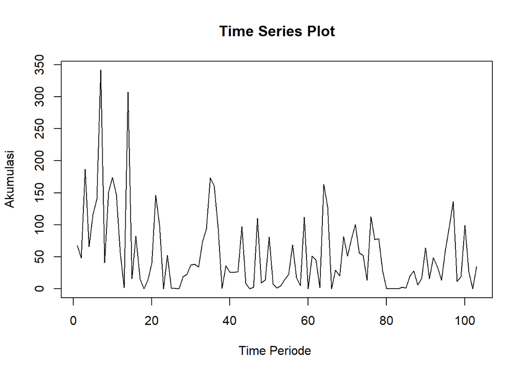

```r
ts.plot(data_training.ts, xlab="Time Periode ", ylab="Akumulasi",
        main = "Time Series Plot")
```

#### Plot ACF

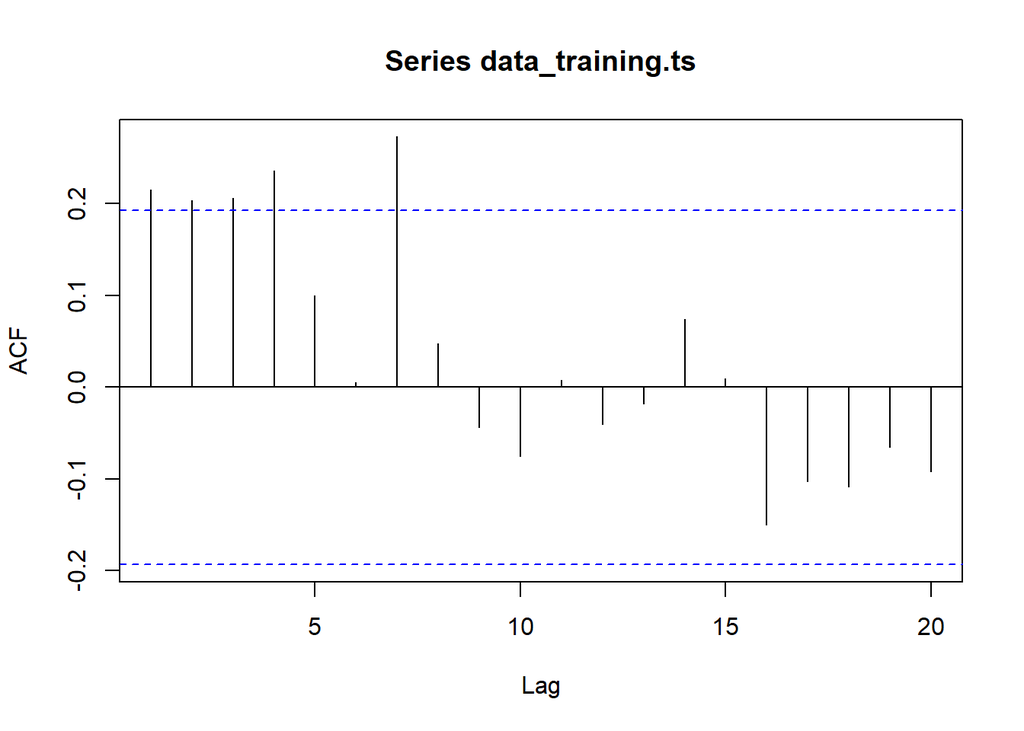

```r
acf(data_training.ts)
```

Berdasarkan plot ACF, terlihat bahwa plot ACF pada data tersebut cenderung *tails off* dan membentuk gelombang sinus.

dari plot juga dapat dikatakan bahwa plot ACF cut off pada lag 7

#### Uji ADF

```r
tseries::adf.test(data_training.ts)
```

```
##
##  Augmented Dickey-Fuller Test
##
## data:  data_training.ts
## Dickey-Fuller = -3.3858, Lag order = 4, p-value = 0.06066
## alternative hypothesis: stationary
```

$H_0$ : Data tidak stasioner dalam rataan

$H_1$ : Data stasioner dalam rataan

Berdasarkan uji ADF tersebut, didapat *p-value* sebesar 0.06066 yang lebih besar dari taraf nyata 5% sehingga tak tolak $H_0$ dan menandakan bahwa data tidak stasioner dalam rataan.

#### Plot Boxcox

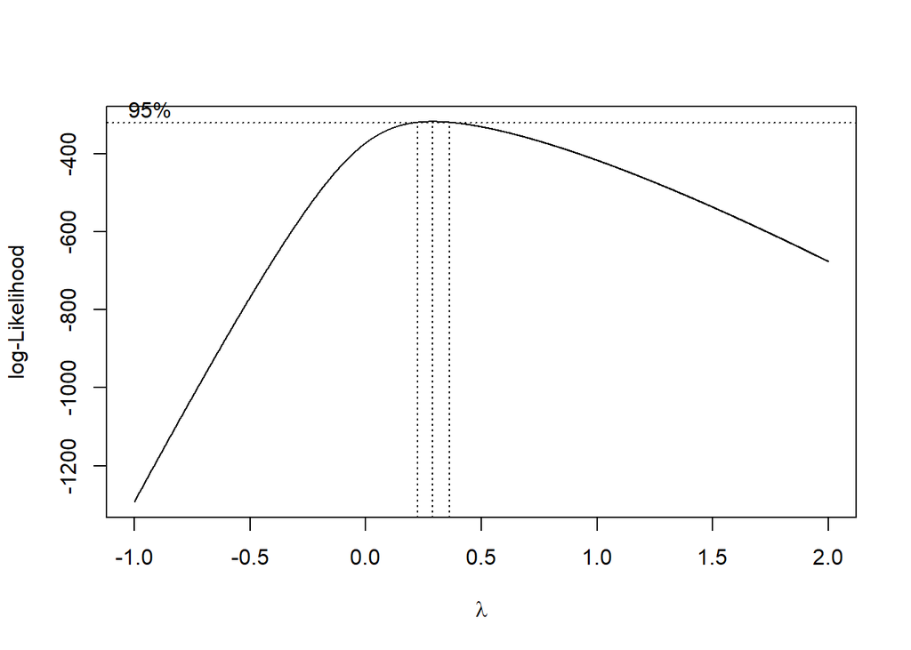

```r
index_2 <- seq(1:103)
bc = boxcox(data_training.ts~index_2, lambda = seq(-1,2,by=0.001))
```

```r
#Nilai Rounded Lambda
lambda <- bc$x[which.max(bc$y)]
lambda
```

```
## [1] 0.289
```

```r
#SK
bc$x[bc$y > max(bc$y) - 1/2 * qchisq(.95,1)]
```

```
##   [1] 0.225 0.226 0.227 0.228 0.229 0.230 0.231 0.232 0.233 0.234 0.235 0.236
##  [13] 0.237 0.238 0.239 0.240 0.241 0.242 0.243 0.244 0.245 0.246 0.247 0.248
##  [25] 0.249 0.250 0.251 0.252 0.253 0.254 0.255 0.256 0.257 0.258 0.259 0.260
##  [37] 0.261 0.262 0.263 0.264 0.265 0.266 0.267 0.268 0.269 0.270 0.271 0.272
##  [49] 0.273 0.274 0.275 0.276 0.277 0.278 0.279 0.280 0.281 0.282 0.283 0.284
##  [61] 0.285 0.286 0.287 0.288 0.289 0.290 0.291 0.292 0.293 0.294 0.295 0.296
##  [73] 0.297 0.298 0.299 0.300 0.301 0.302 0.303 0.304 0.305 0.306 0.307 0.308
##  [85] 0.309 0.310 0.311 0.312 0.313 0.314 0.315 0.316 0.317 0.318 0.319 0.320
##  [97] 0.321 0.322 0.323 0.324 0.325 0.326 0.327 0.328 0.329 0.330 0.331 0.332
## [109] 0.333 0.334 0.335 0.336 0.337 0.338 0.339 0.340 0.341 0.342 0.343 0.344
## [121] 0.345 0.346 0.347 0.348 0.349 0.350 0.351 0.352 0.353 0.354 0.355 0.356
## [133] 0.357 0.358 0.359 0.360 0.361
```

Gambar di atas menunjukkan nilai *rounded value* ($\lambda$) optimum sebesar **0.289** dan pada selang kepercayaan 95% nilai memiliki batas bawah **0.225** dan batas atas **0.361**. Selang tersebut tidak memuat nilai satu sehingga dapat dikatakan bahwa data curah hujan bogor tidak stasioner dalam ragam.

### SUMMARY Data Training

Pada data ini terdapat 103 periode, dapat di identifikasi stasionernya dengan melakukan uji ACF dengan hasil Tail off lalu dilakukan uji stasioner bagi rataan Menggunakan uji ADF.hasil p-value $0.06066$ yang lebih besar dari taraf nyata 5% sehingga tak tolak $H_0$ dan menandakan bahwa data tidak stasioner dalam rataan. lalu dilakukan uji stasioner bagi ragam Menggunakan Box-Cox dengan hasil lambda $0.289$ dan pada selang kepercayaan 95% nilai memiliki batas bawah $0.225$ dan batas atas $0.361$.

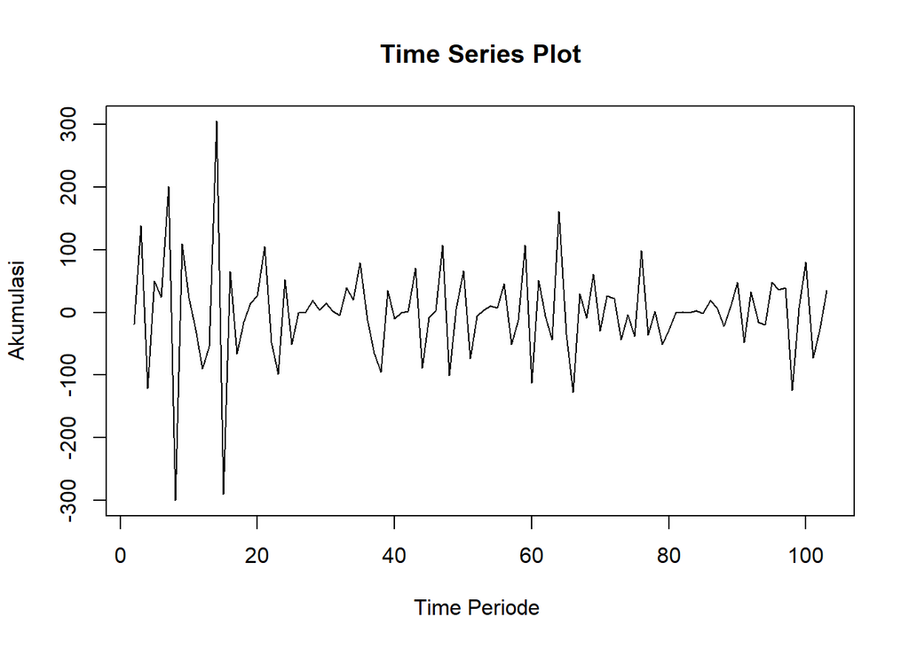

```r
train.diff<-diff(data_training.ts, differences = 1)
plot.ts(train.diff, xlab="Time Periode ", ylab="Akumulasi",
        main = "Time Series Plot")
```

Berdasarkan plot data deret waktu, terlihat bahwa data sudah stasioner dalam rataan ditandai dengan data bergerak pada nilai tengah tertentu (tidak terdapat trend ataupun musiman pada data)

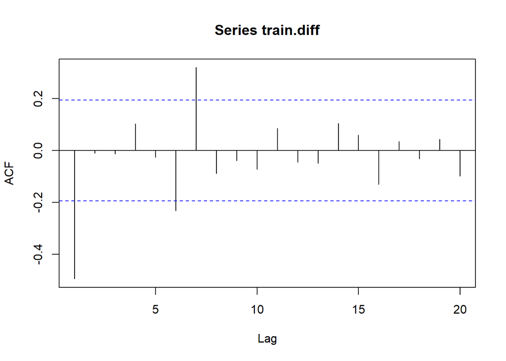

```r
acf(train.diff)
```

Bedasarakan plot di atas, terlihat bahwa plot ACF cuts off pada after lag 7. hal ini menandakan data sudah stasioner dalam rataan dan ketidakstasioneran telah teratasi

```r
tseries::adf.test(train.diff)
```

```
##
##  Augmented Dickey-Fuller Test
##
## data:  train.diff
## Dickey-Fuller = -5.9013, Lag order = 4, p-value = 0.01
## alternative hypothesis: stationary
```

Hipotesis Uji ADF $H_0$ : Data tidak stasioner dalam rataan

$H_1$ : Data stasioner dalam rataan

Berdasarkan uji ADF tersebut, didapat *p-value* sebesar 0.01 yang lebih kecil dari taraf nyata 5% sehingga tolak $H_0$ dan menandakan bahwa data stasioner dalam rataan. Hal ini sesuai dengan hasil eksplorasi menggunakan plot time series dan plot ACF.

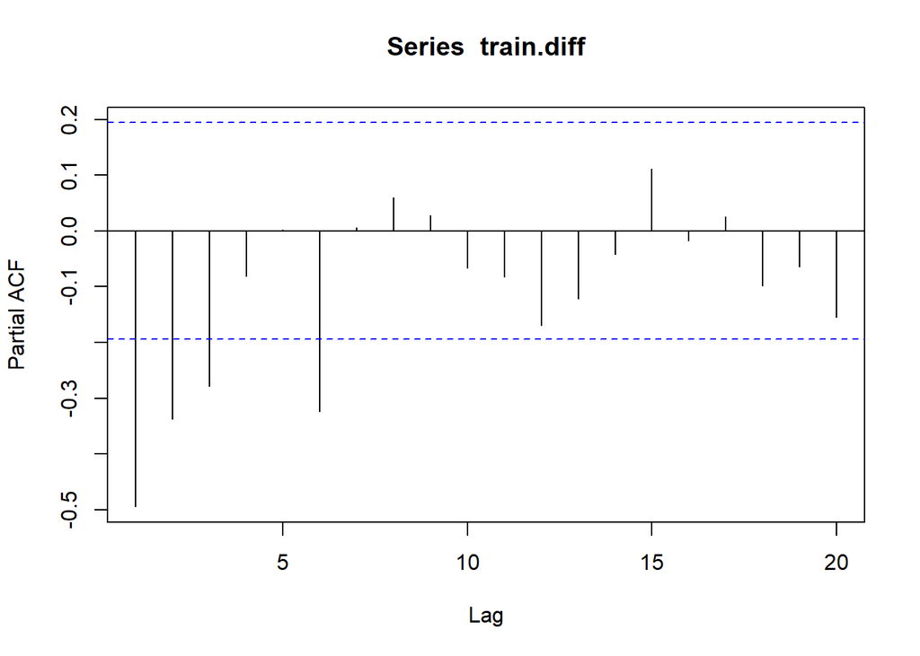

```r
pacf(train.diff)
```

Bedasarkan plot diatas, terlihat bahwa plot PACF tails off maka model tentatifnya dari model adalah ARIMA(1,1,7)

```r
eacf(train.diff)
```

```
## AR/MA
##   0 1 2 3 4 5 6 7 8 9 10 11 12 13
## 0 x o o o o x x o o o o  o  o  o
## 1 x o o o o o x o o o o  o  o  o
## 2 x o o o o o x o o o o  o  o  o
## 3 x o o o o o x o o o o  o  o  o
## 4 o o x o o o x o o o o  o  o  o
## 5 o x x x o o o o o o o  o  o  o
## 6 o o o x o x o o o o o  o  o  o
## 7 x o o x o o o o o o o  o  o  o
```

Identifikasi model menggunakan plot EACF dilakukan dengan melihat ujung segitiga pada pola segitiga nol. Dalam hal ini model tentatif yang terbentuk adalah ARIMA(1,1,7), ARIMA(2,1,7), ARIMA(3,1,7), ARIMA(4,1,7)dan ARIMA (5,1,5)

```r
model1.da<-  arima(train.diff, order = c(1,0,7))
summary(model1.da)
```

```
##
## Call:
## arima(x = train.diff, order = c(1, 0, 7))
##
## Coefficients:
##           ar1      ma1      ma2      ma3      ma4      ma5      ma6     ma7
##       -0.6768  -0.1150  -0.6131  -0.0128  -0.0798  -0.1441  -0.2618  0.2265
## s.e.   0.1523   0.1699   0.1556   0.1105   0.1204   0.1376   0.0926  0.1164
##       intercept
##         -0.6401
## s.e.     0.2587
##
## sigma^2 estimated as 3015:  log likelihood = -556.05,  aic = 1130.09
##
## Training set error measures:
```

```
##               ME RMSE MAE MPE MAPE
## Training set NaN  NaN NaN NaN  NaN
```

```r
lmtest::coeftest(model1.da)
```

```
##
## z test of coefficients:
##
##            Estimate Std. Error z value  Pr(>|z|)
## ar1       -0.676790   0.152321 -4.4432 8.863e-06 ***
## ma1       -0.114996   0.169873 -0.6770  0.498437
## ma2       -0.613107   0.155591 -3.9405 8.131e-05 ***
## ma3       -0.012831   0.110541 -0.1161  0.907597
## ma4       -0.079759   0.120444 -0.6622  0.507837
## ma5       -0.144058   0.137609 -1.0469  0.295161
## ma6       -0.261763   0.092633 -2.8258  0.004716 **
## ma7        0.226519   0.116395  1.9461  0.051639 .
## intercept -0.640080   0.258678 -2.4744  0.013345 *
## ---
## Signif. codes:  0 '***' 0.001 '**' 0.01 '*' 0.05 '.' 0.1 ' ' 1
```

```r
model2.da<-  arima(train.diff, order = c(2,0,7))
summary(model2.da)
```

```
##
## Call:
## arima(x = train.diff, order = c(2, 0, 7))
##
## Coefficients:
##           ar1      ar2     ma1      ma2      ma3      ma4      ma5      ma6
##       -0.8463  -0.1600  0.0420  -0.5949  -0.1337  -0.0806  -0.1567  -0.2770
## s.e.   0.3616   0.2962  0.3521   0.1552   0.2581   0.1154   0.1392   0.0914
##          ma7  intercept
##       0.2009    -0.6430
## s.e.  0.1352     0.2605
##
## sigma^2 estimated as 3008:  log likelihood = -555.9,  aic = 1131.79
##
## Training set error measures:
```

```
##               ME RMSE MAE MPE MAPE
## Training set NaN  NaN NaN NaN  NaN
```

```r
lmtest::coeftest(model2.da)
```

```
##
## z test of coefficients:
##
##            Estimate Std. Error z value  Pr(>|z|)
## ar1       -0.846344   0.361583 -2.3407 0.0192494 *
## ar2       -0.159991   0.296225 -0.5401 0.5891295
## ma1        0.041980   0.352118  0.1192 0.9051009
## ma2       -0.594927   0.155170 -3.8340 0.0001261 ***
## ma3       -0.133690   0.258131 -0.5179 0.6045172
## ma4       -0.080563   0.115433 -0.6979 0.4852227
## ma5       -0.156660   0.139192 -1.1255 0.2603775
## ma6       -0.277017   0.091438 -3.0296 0.0024492 **
## ma7        0.200879   0.135245  1.4853 0.1374644
## intercept -0.643030   0.260547 -2.4680 0.0135873 *
## ---
## Signif. codes:  0 '***' 0.001 '**' 0.01 '*' 0.05 '.' 0.1 ' ' 1
```

```r
model3.da<-  arima(train.diff, order = c(3,0,7))
summary(model3.da)
```

```
##
## Call:
## arima(x = train.diff, order = c(3, 0, 7))
##
## Coefficients:
##           ar1      ar2      ar3     ma1     ma2      ma3      ma4      ma5
##       -1.1899  -1.2496  -0.8227  0.3877  0.2169  -0.2604  -0.8777  -0.1837
## s.e.   0.0991   0.0924   0.1179  0.1548  0.1585   0.1613   0.1788   0.1182
##           ma6     ma7  intercept
##       -0.3137  0.0309    -0.6673
## s.e.   0.1105  0.1244     0.2482
##
## sigma^2 estimated as 2847:  log likelihood = -553.75,  aic = 1129.5
##
## Training set error measures:
```

```
##               ME RMSE MAE MPE MAPE
## Training set NaN  NaN NaN NaN  NaN
```

```r
lmtest::coeftest(model3.da)
```

```
##
## z test of coefficients:
##
##            Estimate Std. Error  z value  Pr(>|z|)
## ar1       -1.189854   0.099147 -12.0009 < 2.2e-16 ***
## ar2       -1.249557   0.092390 -13.5249 < 2.2e-16 ***
## ar3       -0.822652   0.117903  -6.9774 3.007e-12 ***
## ma1        0.387660   0.154774   2.5047  0.012256 *
## ma2        0.216896   0.158475   1.3686  0.171111
## ma3       -0.260356   0.161332  -1.6138  0.106574
## ma4       -0.877708   0.178822  -4.9083 9.188e-07 ***
## ma5       -0.183679   0.118223  -1.5537  0.120263
## ma6       -0.313747   0.110505  -2.8392  0.004523 **
## ma7        0.030938   0.124385   0.2487  0.803573
## intercept -0.667262   0.248210  -2.6883  0.007182 **
## ---
## Signif. codes:  0 '***' 0.001 '**' 0.01 '*' 0.05 '.' 0.1 ' ' 1
```

```r
model4.da<-  arima(train.diff, order = c(4,0,7))
summary(model4.da)
```

```
##
## Call:
## arima(x = train.diff, order = c(4, 0, 7))
##
## Coefficients:
##           ar1      ar2     ar3     ar4      ma1      ma2      ma3      ma4
##       -0.3689  -0.2610  0.2059  0.7109  -0.4316  -0.0866  -0.3741  -0.6863
## s.e.   0.2372   0.2698  0.2857  0.1938   0.2537   0.1822   0.1381   0.1407
##          ma5      ma6     ma7  intercept
##       0.5696  -0.1896  0.1985    -0.6752
## s.e.  0.2281   0.1221  0.1409     0.3203
##
## sigma^2 estimated as 2835:  log likelihood = -553.37,  aic = 1130.73
##
## Training set error measures:
```

```
##               ME RMSE MAE MPE MAPE
## Training set NaN  NaN NaN NaN  NaN
```

```r
lmtest::coeftest(model4.da)
```

```
##
## z test of coefficients:
##
##            Estimate Std. Error z value  Pr(>|z|)
## ar1       -0.368868   0.237189 -1.5552 0.1199068
## ar2       -0.260960   0.269766 -0.9674 0.3333657
## ar3        0.205896   0.285744  0.7206 0.4711809
## ar4        0.710938   0.193762  3.6691 0.0002434 ***
## ma1       -0.431614   0.253718 -1.7012 0.0889132 .
## ma2       -0.086603   0.182236 -0.4752 0.6346262
## ma3       -0.374053   0.138066 -2.7092 0.0067440 **
## ma4       -0.686293   0.140688 -4.8781 1.071e-06 ***
## ma5        0.569602   0.228099  2.4972 0.0125189 *
## ma6       -0.189560   0.122070 -1.5529 0.1204521
## ma7        0.198528   0.140896  1.4090 0.1588220
## intercept -0.675183   0.320328 -2.1078 0.0350496 *
## ---
## Signif. codes:  0 '***' 0.001 '**' 0.01 '*' 0.05 '.' 0.1 ' ' 1
```

```r
model6.da<-  arima(train.diff, order = c(5,0,5))
summary(model6.da)
```

```
##
## Call:
## arima(x = train.diff, order = c(5, 0, 5))
##
## Coefficients:
##           ar1      ar2      ar3     ar4     ar5     ma1      ma2      ma3
##       -1.3836  -1.1155  -0.5741  0.3422  0.3773  0.5818  -0.0292  -0.3744
## s.e.   0.2476   0.3322   0.3532  0.2612  0.1011  0.2651   0.1421   0.0944
##           ma4      ma5  intercept
##       -0.9376  -0.2395    -0.6598
## s.e.   0.1385   0.2465     0.2814
##
## sigma^2 estimated as 2784:  log likelihood = -552.6,  aic = 1127.21
##
## Training set error measures:
```

```
##               ME RMSE MAE MPE MAPE
## Training set NaN  NaN NaN NaN  NaN
```

```r
lmtest::coeftest(model6.da)
```

```
##
## z test of coefficients:
##
##            Estimate Std. Error z value  Pr(>|z|)
## ar1       -1.383553   0.247601 -5.5878 2.299e-08 ***
## ar2       -1.115535   0.332166 -3.3584 0.0007840 ***
## ar3       -0.574121   0.353176 -1.6256 0.1040361
## ar4        0.342218   0.261201  1.3102 0.1901375
## ar5        0.377276   0.101145  3.7300 0.0001915 ***
## ma1        0.581836   0.265125  2.1946 0.0281941 *
## ma2       -0.029162   0.142069 -0.2053 0.8373643
## ma3       -0.374382   0.094372 -3.9671 7.275e-05 ***
## ma4       -0.937599   0.138505 -6.7694 1.293e-11 ***
## ma5       -0.239466   0.246495 -0.9715 0.3313064
## intercept -0.659815   0.281363 -2.3451 0.0190235 *
## ---
## Signif. codes:  0 '***' 0.001 '**' 0.01 '*' 0.05 '.' 0.1 ' ' 1
```

```r
#bikin perbandingan nilai AIC dari model1-model6 dengan data frame
Nilai_AIC<-data.frame(model1.da$aic,model2.da$aic,model3.da$aic,model4.da$aic,model6.da$aic)
colnames(Nilai_AIC)<-c("Model1","Model2","Model3","Model4","Model6")
rownames(Nilai_AIC)<-c("AIC")
Nilai_AIC
```

```
##       Model1  Model2   Model3   Model4   Model6
## AIC 1130.092 1131.79 1129.497 1130.732 1127.205
```

# Kesimpulan

Ketika dilakukan penanganan stasioner rataan pada data training dengan melakukan differencing satu kali, didapat model ARIMA(5,1,5) sebagai model terbaik dengan nilai AIC terkecil sebesar 1127.205. Akan tetapi hasil dari Model ARIMA (5,1,5) tidak dapat dikatakan sebagai model yang valid karena nilai dari salah satu AR atau MA ada yang tidak signifikan. Hal ini dikarenakan Pola data yang cenderung memiliki sifat data musiman, mengingat bahwa ini adalah data curah hujan yang pastinya memiliki periode musim hujan tertentu sehingga yang baik adalah diperlukan analisis lebih lanjut dengan metode model SARIMA atau yang lainnya.